# Customer Churn Analysis

Nils Gandlau

25 11 2020

## Research Questions

**Question:** Who is churning? Which are common characteristics among customers who stay longer?

**Implications:** Deciding which advertisement channels is the best to acquire long-term customers. Discovery of customer characteristics associated with long-term relationships allows you to better choose your target groups when advertising.

**Question:** Do coupons improve customer churn?

**Implications:** Decide whether coupons are a investment with a positive return.

**Question:** How long are customers staying?

**Implications:** Understand the long-term growth capabilities of your business.

## Prerequisites

- Definition of Churn: Customers who have not bought in the previous 1 month. (chosen by the user)
- Choosing covariates for the regression (outsourced to us)
- Choosing the right model (outsourced to us)

## Who is churning?

**Method:** Survival Analysis; Cox Model; Parametric Proportional Hazards Model

**User:** Filter for min. number of purchases (e.g. remove one-time buyers who would bias the results)

```
## Call:
## coxph(formula = Surv(survTime, isChurn) ~ acqChannel + age +
##     salary + productCategory, data = data)
##
##   n= 2973, number of events= 827
##
##                                      coef exp(coef)  se(coef)      z Pr(>|z|)
## acqChannelgoogle                 0.047458  1.048602  0.076232  0.623 0.533580
## age                             -0.009582  0.990464  0.002408 -3.980  6.9e-05
## salarylow                       -0.445909  0.640242  0.119819 -3.722 0.000198
## salarymid                       -0.390518  0.676706  0.131893 -2.961 0.003068
## productCategoryEntertainment     0.075047  1.077935  0.155282  0.483 0.628884
## productCategoryFitness          -0.020209  0.979994  0.158651 -0.127 0.898641
## productCategoryIndustrial        0.044065  1.045050  0.156198  0.282 0.777859
## productCategoryLifestyle         0.109003  1.115166  0.127483  0.855 0.392531
## productCategoryMedical           0.001185  1.001185  0.136239  0.009 0.993062
## productCategoryPets and Animals  0.034334  1.034930  0.156682  0.219 0.826547
##
## acqChannelgoogle
## age                             ***
## salarylow                       ***
## salarymid                       **
## productCategoryEntertainment
## productCategoryFitness
## productCategoryIndustrial
## productCategoryLifestyle
## productCategoryMedical
## productCategoryPets and Animals
## ---
## Signif. codes:  0 '***' 0.001 '**' 0.01 '*' 0.05 '.' 0.1 ' ' 1
##
##                                 exp(coef) exp(-coef) lower .95 upper .95
## acqChannelgoogle                   1.0486     0.9537    0.9031    1.2176
## age                                0.9905     1.0096    0.9858    0.9951
## salarylow                          0.6402     1.5619    0.5062    0.8097
## salarymid                          0.6767     1.4777    0.5226    0.8763
## productCategoryEntertainment       1.0779     0.9277    0.7951    1.4614
## productCategoryFitness             0.9800     1.0204    0.7181    1.3374
## productCategoryIndustrial          1.0451     0.9569    0.7695    1.4194
## productCategoryLifestyle           1.1152     0.8967    0.8686    1.4317
## productCategoryMedical             1.0012     0.9988    0.7666    1.3076
## productCategoryPets and Animals    1.0349     0.9662    0.7613    1.4070
##
## Concordance= 0.537  (se = 0.011 )
## Likelihood ratio test= 31.53  on 10 df,   p=5e-04
## Wald test            = 32.75  on 10 df,   p=3e-04
## Score (logrank) test = 33.13  on 10 df,   p=3e-04
```

**🗻Insights**

**📈You should advertise on:**

- Google or Facebook - it does not matter for churn

### Visual Inspection

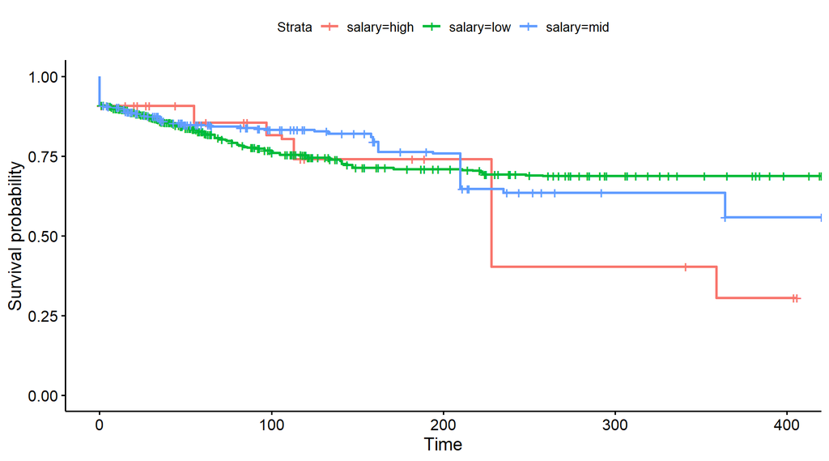

Survival Time Distribution for each category.

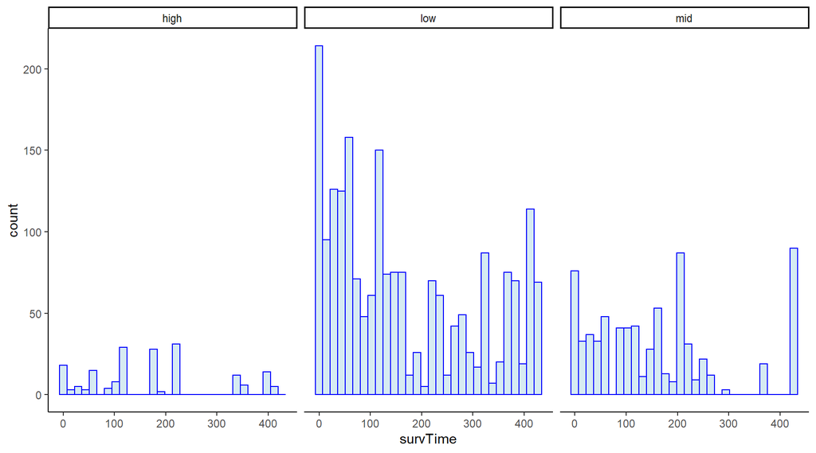

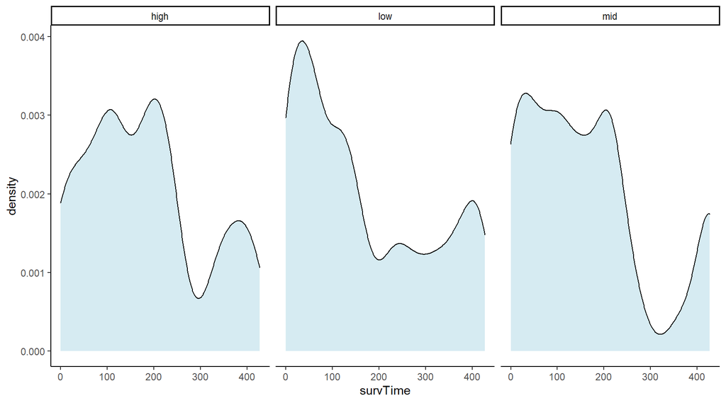

## Which Product To Lead With?

The goal is to identify the products that are best to lead with. We want to identify products (product categories) that customers have bought first are good to introduce customers with. Customers who purchase these products have a higher chance to come back.

To begin the analysis we have to define a time interval within which customers *usually* make their second purchases. This time interval is different for each firm. One way to come up with a good time interval is to compute quantiles. An 80%-quantile will tell you the number of days within which 80% of your customers have made a second purchase. For example, if your 80%-quantile is 35 days, you know that 80% of your customers have made their second purchase within 35 days after making their first purchase.

```
##   20%   40%   60%   80%
##   0.0  14.0  43.6 121.8
```

- 20% of customers make their second purchase on the same day they make their first
- 40% of customers make their second purchase within 14 days after making their first.
- 60% of customers make their second purchase within 43 days (~1.5 months) after making their first.
- 80% of customers make their seocnd purchase within 121 days (~4 months) after making their first.

**=> Customers who did not purchase a second time after 120 days are classified as One-Timers**.

To find out which product to lead with, we have two options which vary in the degree of complexity.

**Option 1:** The easiest method is to to a descriptive variant and compute `num2ndPurchases / num1stPurchases` by product category.

**Option 2:** The advanced method would be to fit a logistic regression that models Pr(2nd purchase | product category), which would give you an *option to control for other variables*.

Option 1 yields the following:

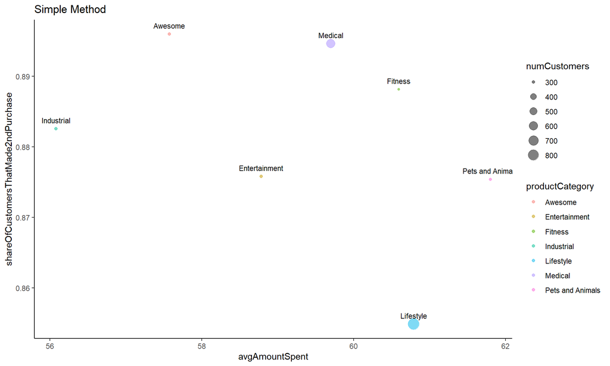

Insights:

- Product categories “Awesome”, “Medical”, and “Fitness” are the best 3 product categories to lead with. Customers whose first purchase is a product from one of these categories have a >85% chance of making a second purchase.
- 15% of customers whose first purchase was a product from the “Lifestyle”-category have remained One-Timers. They did not make a 2nd purchase (within the usual 2nd-purchase-timeframe).  
  => You should not introduce customers to the brand with products from your Lifestyle category!

Option 2 is to run a logistic regression. This allows us to control for other variables. In this analysis, we compute the probability of a customer making a second purchachase given that he first buys a product from category X, while controlling for salary, age and acquisition channel.

```
##
## Call:
## glm(formula = made2ndPurchase ~ productCategory + salary + age +
##     acqChannel, family = "binomial", data = data)
##
## Deviance Residuals:
##     Min       1Q   Median       3Q      Max
## -2.1682   0.4604   0.4979   0.5417   0.6075
##
## Coefficients:
##                                  Estimate Std. Error z value Pr(>|z|)
## (Intercept)                      2.144917   0.330603   6.488  8.7e-11 ***
## productCategoryEntertainment    -0.201170   0.258680  -0.778   0.4368
## productCategoryFitness          -0.084803   0.264913  -0.320   0.7489
## productCategoryIndustrial       -0.141563   0.261625  -0.541   0.5884
## productCategoryLifestyle        -0.382848   0.212474  -1.802   0.0716 .
## productCategoryMedical          -0.015371   0.231908  -0.066   0.9472
## productCategoryPets and Animals -0.204234   0.258744  -0.789   0.4299
## salarylow                        0.019801   0.238203   0.083   0.9338
## salarymid                       -0.008948   0.254330  -0.035   0.9719
## age                              0.001223   0.003793   0.322   0.7471
## acqChannelgoogle                -0.181441   0.120929  -1.500   0.1335
## ---
## Signif. codes:  0 '***' 0.001 '**' 0.01 '*' 0.05 '.' 0.1 ' ' 1
##
## (Dispersion parameter for binomial family taken to be 1)
##
##     Null deviance: 2214.4  on 2972  degrees of freedom
## Residual deviance: 2204.9  on 2962  degrees of freedom
## AIC: 2226.9
##
## Number of Fisher Scoring iterations: 4
```

Insights:

- There is no difference in the probability of making a second purchase when the first purchase was made in one of Entertainment, Fitness, Industrial, Medical or Pets&Animals categories.
- But customers who made their first purchase with a Lifestyle product decreases the odds of making a second purchase by a factor of `exp(-0.38) = 0.68` compared to the other product categories. This finding is consistent with the plot above. (that number seems quite high?)